# Carbon Trading in the State of Maryland

Albert Wang

5/2/2019

### Introduction

Carbon trading is a government program that allows comapanies and facilities to purchase emissions credits at a set market price. Theoretically, market prices increase with time, thus increasing costs for facilities to emit pollutants, and reducing emissions gradually over time. However, the justice of carbon trading programs has been called into question in the state of California. Cushing et al. [found](https://journals.plos.org/plosmedicine/article?id=10.1371/journal.pmed.1002604) that the implementation of a cap-and-trade program actually led to increased emissions in communities of color.

This project aims to replicate Cushing et al.’s methods in the state of Maryland, my home state.

The [Regional Greenhouse Gas Initiative](https://www.rggi.org/) (RGGI) is a carbon trading program for states in the northeast and Atlantic United States. Cooperating states include Connecticut, Delaware, Maine, Maryland, Massachusetts, New Hampshire, New York, Rhode Island, and Vermont. Maryland has participated in RGGI since 2007 ([source](https://mde.maryland.gov/programs/air/climatechange/rggi/pages/index.aspx)).

### Finding Data

Emissions data was collected from the website of the Environmental Protection Agency [here](https://www.epa.gov/ghgreporting/ghg-reporting-program-data-sets), under the Greenhouse Gas Reporting Program (GHGRP). Facilities reported this data to the EPA on August 19, 2018. Units for emissions data are in metric tons of carbon dioxide equivalent using GWP’s from IPCC’s AR4.

Additionally, We perform some basic data tidying to have the structure of our data fram conform to industry standards of tidy data, thus making it easier to work with.

```r
emissions <- read_excel(
  "2017_data_summary_spreadsheets/ghgp_data_by_year_8_19_2018.xlsx") %>%
  set_tidy_names(syntactic = TRUE) %>%
  rename(
    zip_code = Zip.Code,
    '2011' = X2011.Total.reported.direct.emissions,
    '2012' = X2012.Total.reported.direct.emissions,
    '2013' = X2013.Total.reported.direct.emissions,
    '2014' = X2014.Total.reported.direct.emissions,
    '2015' = X2015.Total.reported.direct.emissions,
    '2016' = X2016.Total.reported.direct.emissions,
    '2017' = X2017.Total.reported.direct.emissions
  ) %>%
  gather('2011', '2012', '2013', '2014', '2015', '2016', '2017', key = "year", value = "total_emissions")
```

```
## Facility Id -> Facility.Id
## FRS Id -> FRS.Id
## Facility Name -> Facility.Name
## Zip Code -> Zip.Code
## Primary NAICS Code -> Primary.NAICS.Code
## Latest Reported Industry Type (subparts) -> Latest.Reported.Industry.Type..subparts.
## Latest Reported Industry Type (sectors) -> Latest.Reported.Industry.Type..sectors.
## 2017 Total reported direct emissions -> X2017.Total.reported.direct.emissions
## 2016 Total reported direct emissions -> X2016.Total.reported.direct.emissions
## 2015 Total reported direct emissions -> X2015.Total.reported.direct.emissions
## 2014 Total reported direct emissions -> X2014.Total.reported.direct.emissions
## 2013 Total reported direct emissions -> X2013.Total.reported.direct.emissions
## 2012 Total reported direct emissions -> X2012.Total.reported.direct.emissions
## 2011 Total reported direct emissions -> X2011.Total.reported.direct.emissions
```

```r
emissions$year = as.numeric(as.character(emissions$year))
emissions$zip_code = as.numeric(as.character(emissions$zip_code))

head(emissions)
```

```
## # A tibble: 6 x 15
##   Facility.Id FRS.Id  Facility.Name   City  State zip_code Address  County
##         <dbl> <chr>   <chr>           <chr> <chr>    <dbl> <chr>    <chr>
## 1    1004377. 110043… 121 REGIONAL D… MELI… TX      75454. 3820 SA… COLLI…
## 2    1010040. 110070… 15-18565/15-18… Haza… KY      40701. 4200 S.… PERRY…
## 3    1010085. 110055… 15-19015        Haza… KY      41701. 1845 S.… PERRY
## 4    1012147. 110070… 17Z Gas Plant … McKi… CA      93251. 22845 H… <NA>
## 5    1000112. 110019… 23rd and 3rd    BROO… NY      11232. 730 3rd… Kings
## 6    1006394. <NA>    29-6 #2 Centra… Blan… NM      87412. <NA>     Rio A…
## # ... with 7 more variables: Latitude <dbl>, Longitude <dbl>,
## #   Primary.NAICS.Code <dbl>,
## #   Latest.Reported.Industry.Type..subparts. <chr>,
## #   Latest.Reported.Industry.Type..sectors. <chr>, year <dbl>,
## #   total_emissions <dbl>
```

Next, we read census data. Census data grouped by zip code was collected from Maryland’s [GIS Data Catalog](https://data.imap.maryland.gov/datasets/eb706b48117b43d482c63d02017fc3ff_1?page=47&selectedAttribute=AREALAND). This dataset had very cryptic column names, so it was necessary to rename these columns into more accessible descriptors.

```r
# from https://data.imap.maryland.gov/datasets/eb706b48117b43d482c63d02017fc3ff_1
census_data <- read_csv("Maryland_Census_Data__ZIP_Code_Tabulation_Areas_ZCTAs.csv") %>%
  rename(
    id = OBJECTID_1,
    zip_code = ZCTA5CE10,
    state_fips_code = FIRST_STAT,
    census_id = FIRST_GEOI,
    fips_class_code = FIRST_CLAS,
    feature_class_code = FIRST_MTFC,
    functional_code = FIRST_FUNC,
    zip_code_number = ZCTA5N,
    state = STATE,
    land_area = AREALAND,
    water_area = AREAWATR,
    population = POP100,
    housing_units = HU100,
    white_population = NHW,
    black_population = NHB,
    american_indian_population = NHAI,
    asian_population = NHA,
    native_hawaiian_population = NHNH,
    other_race_population = NHO,
    nh_total_population = NHT,
    hispanic_population = HISP,
    white_percentage = PNHW,
    black_percentage = PNHB,
    american_indian_percentage = PNHAI,
    asian_percentage = PNHA,
    native_hawaiian_percentage = PNHNH,
    other_race_percentage = PNHO,
    nh_total_percentage = PNHT,
    hispanic_percentage = PHISP
  )
head(census_data)
```

```
## # A tibble: 6 x 40
##      id zip_code state_fips_code census_id fips_class_code
##   <int>    <int>           <int>     <int> <chr>
## 1     1    20601              24   2420601 B5
## 2     2    20602              24   2420602 B5
## 3     3    20603              24   2420603 B5
## 4     4    20606              24   2420606 B5
## 5     5    20607              24   2420607 B5
## 6     6    20608              24   2420608 B5
## # ... with 35 more variables: feature_class_code <chr>,
## #   functional_code <chr>, zip_code_number <int>, state <int>,
## #   land_area <int>, water_area <int>, population <int>,
## #   housing_units <int>, white_population <int>, black_population <int>,
## #   american_indian_population <int>, asian_population <int>,
## #   native_hawaiian_population <int>, other_race_population <int>,
## #   nh_total_population <int>, hispanic_population <int>,
## #   white_percentage <dbl>, black_percentage <dbl>,
## #   american_indian_percentage <dbl>, asian_percentage <dbl>,
## #   native_hawaiian_percentage <dbl>, other_race_percentage <dbl>,
## #   nh_total_percentage <dbl>, hispanic_percentage <dbl>, POP65_ <int>,
## #   PCTPOP65_ <dbl>, MEDAGE <dbl>, VACNS <int>, PVACNS <dbl>, PHOWN <dbl>,
## #   PWOMORT <dbl>, PRENT <dbl>, PLT18SP <dbl>, REPORT_2_P <chr>,
## #   REPORT_9_P <chr>
```

### Exploratory Data Analysis

The first step is to become familiar with our data. We want to focus only on data from the state of Maryland, and group longitudinal data by zip code. Next, to approach the issue from and environmental justice perspective, we want to look at emissions data in combination with racial demographics.

```r
maryland_zip_code_data <- emissions %>%
  filter(State == "MD") %>%
  group_by(zip_code, year) %>%
  summarise(emissions = sum(total_emissions))
head(maryland_zip_code_data)
```

```
## # A tibble: 6 x 3
## # Groups:   zip_code [1]
##   zip_code  year emissions
##      <dbl> <dbl>     <dbl>
## 1   20602. 2011.        NA
## 2   20602. 2012.        NA
## 3   20602. 2013.        NA
## 4   20602. 2014.        NA
## 5   20602. 2015.        NA
## 6   20602. 2016.        NA
```

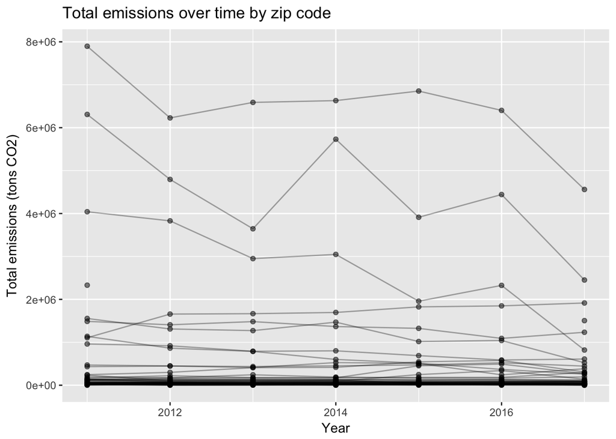

```r
maryland_zip_code_data %>%
  ggplot(aes(year, emissions, group = zip_code, na.rm = TRUE)) +
  geom_point(alpha = 1/2) +
  geom_line(alpha = 1/3) +
  labs(
    title = "Total emissions over time by zip code",
    x = "Year",
    y = "Total emissions (tons CO2)")
```

From the chart above, we can see that some zip code districts in particular have abnormally high emissions rates compared to the remaining zip codes. Let’s find which zip codes these are:

```r
maryland_zip_code_data %>%
  group_by(year) %>%
  summarise(max_emissions = max(emissions, na.rm = TRUE)) %>%
  full_join(maryland_zip_code_data) %>%
  filter(emissions == max_emissions)
```

```
## # A tibble: 7 x 4
##    year max_emissions zip_code emissions
##   <dbl>         <dbl>    <dbl>     <dbl>
## 1 2011.      7897293.   21226.  7897293.
## 2 2012.      6227763.   21226.  6227763.
## 3 2013.      6589058.   21226.  6589058.
## 4 2014.      6630989.   21226.  6630989.
## 5 2015.      6853776.   21226.  6853776.
## 6 2016.      6402801.   21226.  6402801.
## 7 2017.      4560620.   21226.  4560620.
```

The zip code with the highest emissions is 21226 - we’ll find out more about the demographics of this area in the next section.

Looking at census data, we want to take demographic data and calculate two new columns: `non_asian_white_population`, which represents the amount of people in each zip code who are non-Asian and non-white, and `poc_population`, which represents the amount of people of color in each zip code. `non_asian_white_percentage` and `poc_percentage` are the corresponding percentages of the total population, on a scale of 0-100. We distinguish between these two categories because it is often ambiguous (e.g. in this class) as to whether to include Asians in the broader category of people of color.

```r
emissions_and_census_data <- census_data %>%
  select(
    zip_code,
    land_area,
    water_area,
    population,
    housing_units,
    white_population,
    black_population,
    american_indian_population,
    asian_population,
    native_hawaiian_population,
    other_race_population,
    nh_total_population,
    hispanic_population,
    white_percentage,
    black_percentage,
    american_indian_percentage,
    asian_percentage,
    native_hawaiian_percentage,
    other_race_percentage,
    nh_total_percentage,
    hispanic_percentage
    ) %>%
  mutate(
    non_asian_white_population = black_population + american_indian_population + native_hawaiian_population +  other_race_population + hispanic_population,
    poc_population = non_asian_white_population + asian_population,
    non_asian_white_percentage = non_asian_white_population / population * 100,
    poc_percentage = poc_population / population * 100) %>%
  right_join(maryland_zip_code_data, c('zip_code' = 'zip_code'))
head(emissions_and_census_data)
```

```
## # A tibble: 6 x 27
##   zip_code land_area water_area population housing_units white_population
##      <dbl>     <int>      <int>      <int>         <int>            <int>
## 1   20602.  35830723     352762      24955          9736             8466
## 2   20602.  35830723     352762      24955          9736             8466
## 3   20602.  35830723     352762      24955          9736             8466
## 4   20602.  35830723     352762      24955          9736             8466
## 5   20602.  35830723     352762      24955          9736             8466
## 6   20602.  35830723     352762      24955          9736             8466
## # ... with 21 more variables: black_population <int>,
## #   american_indian_population <int>, asian_population <int>,
## #   native_hawaiian_population <int>, other_race_population <int>,
## #   nh_total_population <int>, hispanic_population <int>,
## #   white_percentage <dbl>, black_percentage <dbl>,
## #   american_indian_percentage <dbl>, asian_percentage <dbl>,
## #   native_hawaiian_percentage <dbl>, other_race_percentage <dbl>,
## #   nh_total_percentage <dbl>, hispanic_percentage <dbl>,
## #   non_asian_white_population <int>, poc_population <int>,
## #   non_asian_white_percentage <dbl>, poc_percentage <dbl>, year <dbl>,
## #   emissions <dbl>
```

Consider the zip code 21226, which had abnormally high levels of emissions:

```r
emissions_and_census_data %>% filter(zip_code == 21226 & year == 2011) %>%
  select(zip_code, population, non_asian_white_percentage, poc_percentage)
```

```
## # A tibble: 1 x 4
##   zip_code population non_asian_white_percentage poc_percentage
##      <dbl>      <int>                      <dbl>          <dbl>
## 1   21226.       7561                       19.8           21.7
```

```r
emissions %>% filter(zip_code == 21226) %>%
  select(Facility.Name) %>%
  unique()
```

```
## # A tibble: 4 x 1
##   Facility.Name
##   <chr>
## 1 Brandon Shores LLC
## 2 GRACE
## 3 H A Wagner LLC
## 4 QUARANTINE ROAD LANDFILL
```

Let’s take a look at the previous chart again, but this time with color corresponding to the POC proportion in each zip code.

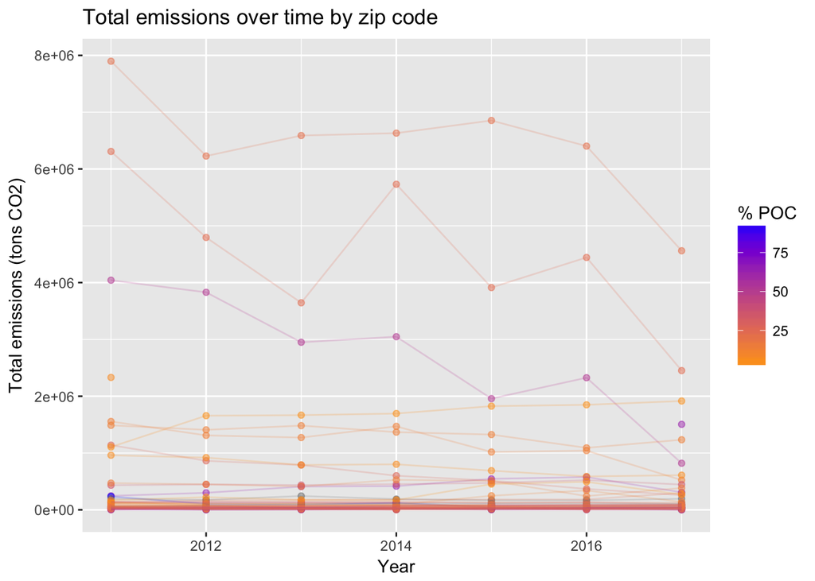

```r
emissions_and_census_data %>%
  ggplot(aes(year, emissions, color = poc_percentage, group = zip_code, na.rm = TRUE, legend = FALSE)) +
  geom_point(alpha = 1/2) +
  geom_line(alpha = 1/5) +
  scale_color_gradient(low="orange", high="blue") +
  labs(
    title = "Total emissions over time by zip code",
    x = "Year",
    y = "Total emissions (tons CO2)",
    color = "% POC")
```

Not super clear - again, a couple of high-emissions outliers hide the majority of our data. Let’s see if we can fix this by grouping together zip codes with similar demographics.

```r
demographic_labels = c("very white/asian", "mostly white/asian", "somewhat white/asian", "kind of white/asian", "barely white/asian")

# Group zip codes into buckets by % poc
blocked_emissions_data <- emissions_and_census_data %>%
  select(year, emissions, poc_percentage, non_asian_white_percentage, zip_code) %>%
  discretizeDF(methods = list(
    poc_percentage = list(method = "interval", breaks = 3, labels = c("low", "medium", "high")),
    non_asian_white_percentage = list(method = "interval", breaks = 5),
    year = list(method = "none"),
    emissions = list(method = "none"),
    zip_code = list(method = "none")
  )) %>%
  group_by(non_asian_white_percentage, year) %>%
  summarise(avg_emissions = mean(emissions, na.rm = TRUE))
```

And the same plot again (NA represents zip codes without demographic data):

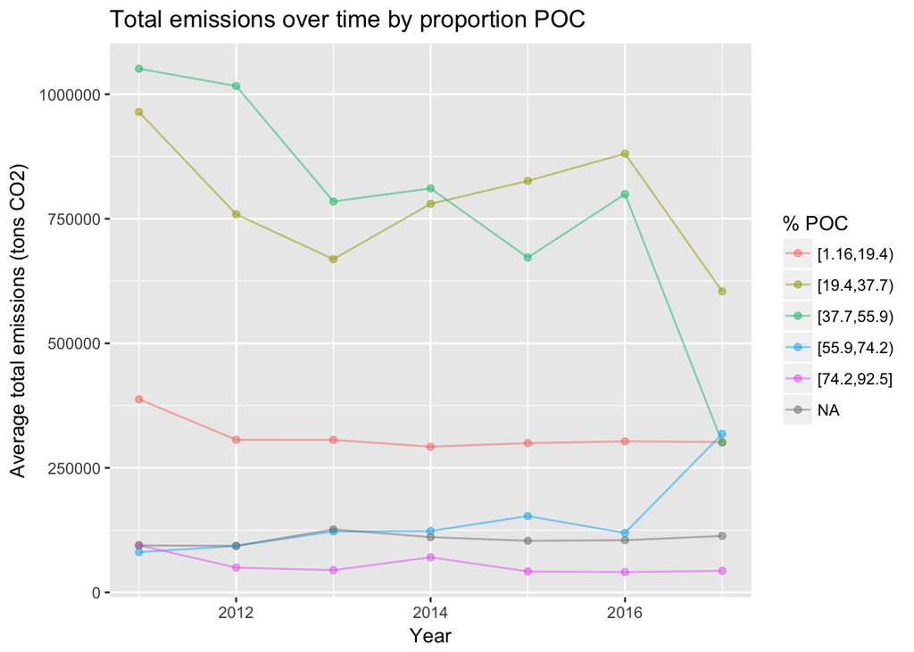

```r
blocked_emissions_data %>%
  ggplot(aes(year, avg_emissions, color = non_asian_white_percentage, group = non_asian_white_percentage, na.rm = TRUE)) +
  geom_point(alpha = 1/2) +
  geom_line(alpha = 1/2) +
  labs(
    title = "Total emissions over time by proportion POC",
    x = "Year",
    y = "Average total emissions (tons CO2)",
    color = "% POC")
```

### Regression

Using these 5 bins of racial diversity, we can compute 5 different linear regressions. We want to look at the relationship between how diverse a zip code is, and the rates at which their emissions levels are changing.

```r
diversity_buckets <- unique(blocked_emissions_data$non_asian_white_percentage)
diversity_buckets <- diversity_buckets[1:(length(diversity_buckets)-1)]

regressions <- vector(mode="list", 5)
slopes <- vector(mode="list", 5)

for (i in seq_along(diversity_buckets)) {
  single_bucket_data <- filter(blocked_emissions_data, non_asian_white_percentage == diversity_buckets[[i]])
  regressions[[i]] <- lm(avg_emissions ~ year, data = single_bucket_data)
  slopes[[i]] <- coef(regressions[[i]])["year"]
}
```

In fact, we no longer have to rely on binning our data to create meaningful charts.

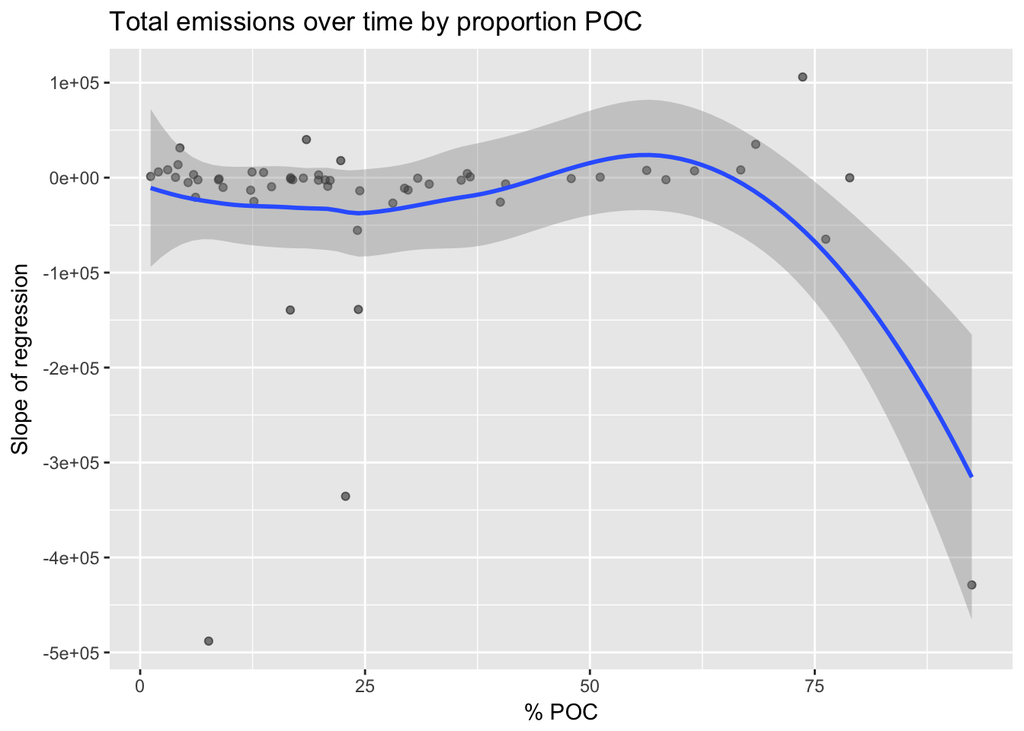

```r
emissions_and_census_data_diversity <- emissions_and_census_data %>%
  filter(!is.nan(emissions) & !is.na(non_asian_white_percentage))

diversity_buckets <- unique(emissions_and_census_data_diversity$non_asian_white_percentage)

regressions <- vector(mode="list", length(diversity_buckets))
slopes <- vector(mode="integer", length(diversity_buckets))

for (i in seq_along(diversity_buckets)) {
  single_bucket_data <- filter(
    emissions_and_census_data_diversity,
    non_asian_white_percentage == diversity_buckets[[i]] & !is.na(emissions))
  regressions[[i]] <- lm(emissions ~ year, data = single_bucket_data)
  slopes[i] <- coef(regressions[[i]])["year"]
}

emissions_and_census_data_diversity$slope <- slopes
emissions_and_census_data_diversity %>%
  filter(year == 2011) %>%
  ggplot(aes(non_asian_white_percentage, slope, na.rm = TRUE)) +
  geom_point(alpha = 1/2) +
  geom_smooth() +
  labs(
    title = "Total emissions over time by proportion POC",
    x = "% POC",
    y = "Slope of regression")
```

### Conclusions

However, there is still value to the datasets engineered in this study. As far as I know, this is the first comprehensive dataset in Maryland that combines demographic data with environmental indicators in a single table, making further analysis much more accessible to other researchers.

Overall, the results of this study present an optimistic outlook for both environmental justice and climate change.